# Week 10: Dimensionality Reduction

How to perform PCA on R We are using R’s USArrests dataset, a dataset from 1973 showing, for each US state, the: 1. rate per 100,000 residents of murder 2. rate per 100,000 residents of rape 3. rate per 100,000 residents of assault 4. % of the population that is urban

Now, we will simplify the data into two-variables data. This does not mean that we are eliminating two variables and keeping two; it means that we are replacing the four variables with two brand new ones called “principal components”. This time we will use R’s princomp function to perform PCA. Preamble: you will need the stats package. Step 1: Standardize the data. You may skip this step if you would rather use princomp’s inbuilt standardization tool*. Step 2: Run pca=princomp(USArrests, cor=TRUE) if your data needs standardizing / princomp(USArrests) if your data is already standardized. Step 3: Now that R has computed 4 new variables (“principal components”), you can choose the two (or one, or three) principal components with the highest variances. You can run summary(pca) to do this. The output will look like this:

```r
data("USArrests")

pca=princomp(USArrests, cor=TRUE)

summary(pca)
```

```
Importance of components:
                          Comp.1    Comp.2    Comp.3     Comp.4
Standard deviation     1.5748783 0.9948694 0.5971291 0.41644938
Proportion of Variance 0.6200604 0.2474413 0.0891408 0.04335752
Cumulative Proportion  0.6200604 0.8675017 0.9566425 1.00000000
```

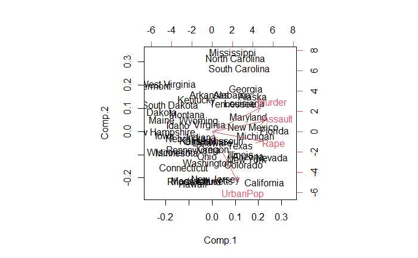

```r
biplot(pca)
```

```r
library(pls)

data("iris")
require(pls)
set.seed (1000)
pcr_model <- pcr(Sepal.Length~., data = iris, scale = TRUE, validation
= "CV")

summary(pcr_model)
```

```
Data:   X dimension: 150 5
    Y dimension: 150 1
Fit method: svdpc
Number of components considered: 5

VALIDATION: RMSEP
Cross-validated using 10 random segments.
       (Intercept)  1 comps  2 comps  3 comps  4 comps  5 comps
CV          0.8308   0.5087   0.5064   0.3915   0.3307   0.3133
adjCV       0.8308   0.5084   0.5059   0.3910   0.3302   0.3126

TRAINING: % variance explained
              1 comps  2 comps  3 comps  4 comps  5 comps
X               56.20    88.62    99.07    99.73   100.00
Sepal.Length    62.71    63.58    78.44    84.95    86.73
```

As you can see, two main results are printed, namely the validation error and the cumulative percentage of variance explained using n components. The cross-validation results are computed for each number of components used so that you can easily check the score with a particular number of components without trying each combination on your own. The pls package also provides a set of methods to plot the results of PCR. For example, you can plot the results of cross validation using the validationplot function. By default, the pcr function computes the root mean squared error and the validationplot function plots this statistic, however you can choose to plot the usual mean squared error or the R2 by setting the val.type argument equal to “MSEP” or “R2” respectively.

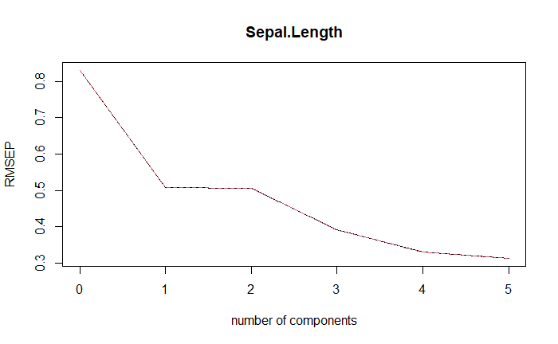

```r
# Plot the root mean squared error
validationplot(pcr_model)
```

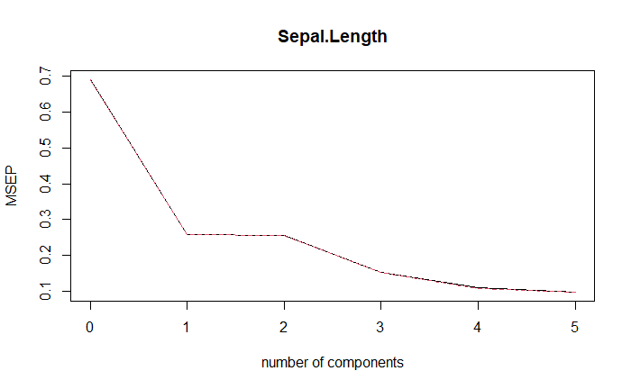

```r
# Plot the cross validation MSE
validationplot(pcr_model, val.type="MSEP")
```

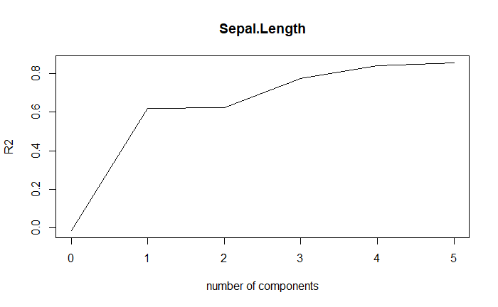

```r
# Plot the R2
validationplot(pcr_model, val.type = "R2")
```

You can plot the predicted vs measured values using the predplot function

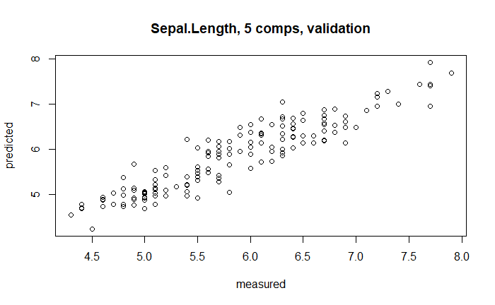

```r
predplot(pcr_model)
```

while the regression coefficients can be plotted using the coefplot function

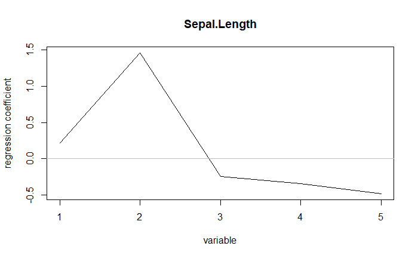

```r
coefplot(pcr_model)
```

Now you can try to use PCR on a traning-test set and evaluate its performance using, for example, using only 3 components.

```r
# Train-test split
train <- iris[1:120,]
y_test <- iris[120:150, 1]
test <- iris[120:150, 2:5]
pcr_model <- pcr(Sepal.Length~., data = train, scale = TRUE,
validation = "CV")
pcr_pred <- predict(pcr_model, test, ncomp = 3)
mean((pcr_pred - y_test)^2)
```

```
[1] 0.213731
```

With the iris dataset there is probably no need to use PCR, in fact, it may even be worse using it. However, I hope this toy example was useful to introduce this model.